# Taller 9: R. Logística Binomial II en R

Métodos Cuantitativos II

M. Constanza Ayala  
maria.ayala@uv.cl  
[Agenda una reunión aquí](https://outlook.office.com/bookwithme/user/6c3f9a95bb9d4c71abbc4d73b48d50d6@uv.cl/meetingtype/HPNElmMJ_UCckWs5QZTpdw2?anonymous&ismsaljsauthenabled&ep=mLinkFromTile)

Escuela de Sociología - Universidad de Valparaíso

17 de junio, 2026

## Pasemos lista mientras descargan los materiales y dejamos todo listo ✨

📂 **Paso 1:** Abrimos nuestro proyecto con doble clic en el archivo `.Rproj`

- Si no tienen proyecto, creamos uno: `File > New Project > New Directory > New Project`
- Creamos carpetas: `data`, `scripts`, `figures`, `output`

💾 **Paso 2:** Movemos el archivo **Script Taller 9 Métodos Cuantitativos II.R** a la carpeta `scripts`

📎 **Paso 3:** Verificamos que la base **base_92_20112024.Rds** esté en la carpeta `data`

> **Todos los materiales los pueden descargar en este link: [Materiales clases](https://github.com/mconstanzaa/met-cuanti-ii-uv-2026)**

## Objetivos de la clase

- **Estimar** modelos de regresión logística binomial con `glm()`
- **Interpretar** coeficientes en escala logit y en términos de odds ratio

## Evaluación recuperativa

Hoy tenemos la **evaluación individual recuperativa** en R. Debes entregar lo siguiente:

- Proyecto de R (`.Rproj`).
- El script (`.R`) que contiene todos los ejercicios individuales solicitados en este taller. Debes crear un script nuevo, no utilices el script de actividades entregado en la clase.
  - En ese script, incluye un título, tu nombre, correo y fecha. Por ejemplo:

```r
# Script Ejercicio recuperativo Métodos Cuantitativos II --------------------------------------------
# M. Constanza Ayala (maria.ayala@uv.cl)
# 16-05-2026
```

**Plazo de entrega:** hoy hasta las 17:45 hrs. al correo maria.ayala@uv.cl. Debe esperar que la profesora confirme la recepción de su correo.

> En caso de utilizar IA, debe reportarlo en un archivo Word, indicando la herramienta y los prompts usados. El uso no reportado será calificado con nota mínima.

## Preparación del entorno

```r
# Ajustes previos ---------------------------------------------------------
options(scipen = 999)

# Paquetes ----------------------------------------------------------------
library(tidyverse)
library(sjPlot)
library(DescTools)

# Base de datos -----------------------------------------------------------
data <- readRDS("data/base_92_20112024.Rds")

# Vista previa
data %>% glimpse()
```

```
Rows: 1,482
Columns: 157
$ id_bu             <chr> "1-92", "2-92", "3-92", "4-92", "5-92", "6-92", "7-9…
$ id_bu_encuesta    <dbl> 1, 2, 3, 4, 5, 6, 7, 8, 9, 10, 11, 12, 13, 14, 15, 1…
$ encuesta          <dbl> 92, 92, 92, 92, 92, 92, 92, 92, 92, 92, 92, 92, 92, …
$ encuesta_a        <dbl> 2024, 2024, 2024, 2024, 2024, 2024, 2024, 2024, 2024…
$ encuesta_m        <dbl> 8, 8, 8, 8, 8, 8, 8, 8, 8, 8, 8, 8, 8, 8, 8, 8, 8, 8…
$ pond              <dbl> 0.2096586, 1.2242271, 0.4620447, 1.6158843, 1.249230…
$ secu              <dbl> 92071, 92173, 92193, 92173, 92071, 92193, 92193, 921…
$ estrato           <dbl> 8, 20, 20, 20, 8, 20, 20, 20, 20, 20, 20, 12, 20, 10…
$ region_3          <dbl+lbl>  6, 13, 13, 13,  6, 13, 13, 13, 13, 13, 13,  8, …
$ zona_u_r          <dbl+lbl> 1, 1, 1, 1, 1, 1, 1, 1, 1, 1, 1, 1, 1, 1, 1, 1, …
$ gse               <dbl+lbl> 4, 3, 3, 3, 4, 3, 3, 2, 3, 3, 2, 4, 3, 3, 3, 3, …
$ percepcion_1_a    <dbl+lbl>  3,  3, 14,  1,  1,  5,  9, 14,  1,  1,  1,  1, …
$ percepcion_1_b    <dbl+lbl>  7,  9, 10, 10,  3, 10, 14,  9,  9,  3,  5,  3, …
```

[output cut: 144 more lines]

## Variables que usaremos

Trabajaremos con tres variables de la **Encuesta CEP N° 92** (agosto–septiembre 2024):

| Variable | Pregunta (resumida) | Escala / Categorías |
| --- | --- | --- |
| `mtf_45_h` | Una pareja del mismo sexo puede criar a un niño/a tan bien como una pareja heterosexual | 1 Muy de acuerdo … 5 Muy en desacuerdo |
| `sexo` | Sexo del encuestado/a | 1 Hombre / 2 Mujer |
| `esc_nivel_1_c` | Escolaridad por nivel | Numérica (0–10) |

> Los valores **-8** (No sabe) y **-9** (No contesta) corresponden a **datos perdidos** y deben recodificarse como `NA` antes de cualquier análisis.

## Preparación de variables

Recodificamos valores perdidos en la VD y en escolaridad con `across()`:

```r
data <- data %>%
  mutate(across(c(mtf_45_h, esc_nivel_1_c), ~ case_when(
    . %in% c(-8, -9) ~ NA_real_,
    TRUE ~ .
  )))
```

Exploramos la distribución original de `mtf_45_h`:

```r
data %>%
  group_by(mtf_45_h) %>%
  summarise(N = n(),
            Porcentaje = round(100 * n() / nrow(data), 1))
```

```
# A tibble: 6 × 3
  mtf_45_h                                N Porcentaje
  <dbl+lbl>                           <int>      <dbl>
1  1 [Muy de acuerdo]                   329       22.2
2  2 [De acuerdo]                       512       34.5
3  3 [Ni de acuerdo ni en desacuerdo]   183       12.3
4  4 [En desacuerdo]                    279       18.8
5  5 [Muy en desacuerdo]                137        9.2
6 NA                                     42        2.8
```

Binarizamos la VD: categoría 1 = “Muy de acuerdo / De acuerdo” (valores 1 y 2); categoría 0 = “Otro” (valores 3, 4 y 5):

```r
data <- data %>%
  mutate(mtf_45_h = case_when(
    mtf_45_h %in% c(1, 2) ~ "Muy de acuerdo / De acuerdo",
    mtf_45_h %in% c(3:5)  ~ "Otro",
    TRUE                   ~ NA_character_
  ))

data %>%
  group_by(mtf_45_h) %>%
  summarise(N = n(),
            Porcentaje = round(100 * n() / nrow(data), 1))
```

```
# A tibble: 3 × 3
  mtf_45_h                        N Porcentaje
  <chr>                       <int>      <dbl>
1 Muy de acuerdo / De acuerdo   841       56.7
2 Otro                          599       40.4
3 <NA>                           42        2.8
```

```r
# Etiquetas en sexo
data$sexo <- factor(data$sexo,
                    levels = c(1:2),
                    labels = c("Hombre", "Mujer"))

# Verificamos NA en las tres variables
data %>%
  summarise(across(c(mtf_45_h, sexo, esc_nivel_1_c),
                   ~ sum(is.na(.))))
```

```
# A tibble: 1 × 3
  mtf_45_h  sexo esc_nivel_1_c
     <int> <int>         <int>
1       42     0             9
```

```r
# Eliminamos casos con NA en VD y escolaridad
data <- data %>%
  drop_na(mtf_45_h, esc_nivel_1_c)

dim(data)
```

```
[1] 1432  157
```

## Estadísticos descriptivos

```r
# Distribución por sexo
data %>%
  group_by(Sexo = sexo) %>%
  summarise(N = n(),
            Porcentaje = round(100 * n() / nrow(data), 1))
```

```
# A tibble: 2 × 3
  Sexo       N Porcentaje
  <fct>  <int>      <dbl>
1 Hombre   562       39.2
2 Mujer    870       60.8
```

```r
# Distribución de la VD
data %>%
  group_by(Homoparentalidad = mtf_45_h) %>%
  summarise(N = n(),
            Porcentaje = round(100 * n() / nrow(data), 1))
```

```
# A tibble: 2 × 3
  Homoparentalidad                N Porcentaje
  <chr>                       <int>      <dbl>
1 Muy de acuerdo / De acuerdo   835       58.3
2 Otro                          597       41.7
```

```r
# Escolaridad
summary(data$esc_nivel_1_c)
```

```
   Min. 1st Qu.  Median    Mean 3rd Qu.    Max.
  0.000   3.000   4.000   4.383   6.000  10.000
```

## Regresión logística binaria

El modelamiento estadístico con **datos binarios** busca **estimar la probabilidad de éxito o fracaso de un evento** como una función de un conjunto de variables independientes.

- La distribución de $Y$ es especificada por las probabilidades de éxito $P(Y=1)=\pi$ o fracaso $P(Y=0)=(1-\pi)$, es decir, sigue una **distribución binomial** ($X \sim Bin(n,\pi)$).
- Hoy existen dos modelos ampliamente usados: **modelos logísticos (logit)** y **modelos probit**.

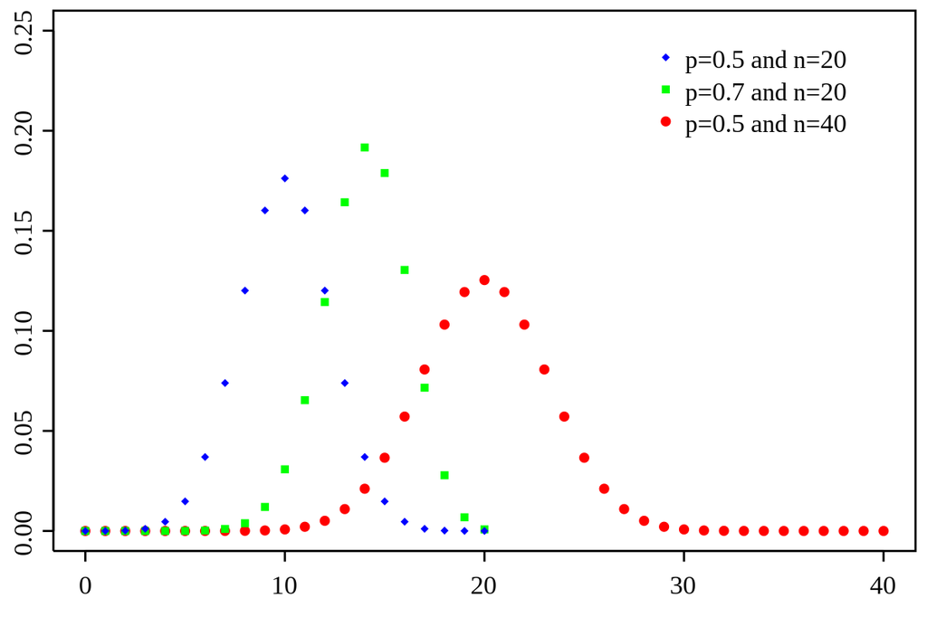

## El modelo: ecuación en log-odds

La ecuación del modelo para este ejemplo es:

$$\log\left(\frac{P(\text{Acuerdo} = 1)}{1 - P(\text{Acuerdo} = 1)}\right) = \hat{\beta}_0 + \hat{\beta}_1 \cdot \text{Mujer} + \hat{\beta}_2 \cdot \text{Escolaridad}$$

Donde:

- El lado izquierdo es el **log-odds** (logit) de que la persona esté de acuerdo con la homoparentalidad
- $\hat{\beta}_0$ es el intercepto: el log-odds esperado cuando todos los predictores valen cero
- $\hat{\beta}_1$ y $\hat{\beta}_2$ indican el cambio en el log-odds asociado a cada predictor
- El **signo** del coeficiente indica la dirección: $b > 0$ aumenta la probabilidad de $Y = 1$; $b < 0$ la reduce

## Estimación con `glm()`

La función `glm()` con `family = "binomial"` estima el modelo logístico por máxima verosimilitud.

```r
# Definimos la categoría de referencia de la VD
data$mtf_45_h <- fct_relevel(as.factor(data$mtf_45_h), "Otro")

# Modelo nulo (solo intercepto)
m0 <- glm(mtf_45_h ~ 1,             data = data, family = "binomial")

# Modelo 1: sexo
m1 <- glm(mtf_45_h ~ sexo,          data = data, family = "binomial")

# Modelo 2: escolaridad
m2 <- glm(mtf_45_h ~ esc_nivel_1_c, data = data, family = "binomial")

# Modelo 3: sexo + escolaridad
m3 <- glm(mtf_45_h ~ sexo + esc_nivel_1_c, data = data, family = "binomial")
```

## Output de `summary()`: lectura del modelo

```r
summary(m3)
```

```
Call:
glm(formula = mtf_45_h ~ sexo + esc_nivel_1_c, family = "binomial",
    data = data)

Coefficients:
              Estimate Std. Error z value         Pr(>|z|)
(Intercept)   -0.60775    0.14115  -4.306 0.00001664108779 ***
sexoMujer      0.77786    0.11204   6.943 0.00000000000384 ***
esc_nivel_1_c  0.11079    0.02451   4.519 0.00000620269277 ***
---
Signif. codes:  0 '***' 0.001 '**' 0.01 '*' 0.05 '.' 0.1 ' ' 1

(Dispersion parameter for binomial family taken to be 1)

    Null deviance: 1945.4  on 1431  degrees of freedom
Residual deviance: 1880.2  on 1429  degrees of freedom
AIC: 1886.2

Number of Fisher Scoring iterations: 4
```

## ¿Qué leemos en el output de `summary()`?

El output entrega tres bloques clave:

**1. Coeficientes**: estimaciones de $\hat{\beta}$ en escala de **log-odds**, con error estándar, estadístico $z$ y p-valor. El test de Wald contrasta $H_0: \beta_k = 0$; se rechaza si $p < .05; p < .01$.

**2. Null deviance y Residual deviance**: la null deviance es el desvío del modelo sin predictores (solo intercepto); la residual deviance es el desvío del modelo con los predictores incluidos. A menor desvío residual, mejor ajuste. La diferencia entre ambos indica cuánto mejora el ajuste al incorporar los predictores.

**3. AIC**: criterio de información de Akaike. Penaliza por el número de parámetros. A menor AIC, mejor ajuste relativo. Útil para comparar modelos estimados sobre los misma muestra.

## Interpretación en escala logit

A partir del output del Modelo 3 (`mtf_45_h ~ sexo + esc_nivel_1_c`):

- **`sexoMujer`** ($\hat{\beta} = 0.78$, $p < .001$): ser mujer se asocia con un **aumento** en los log-odds de estar de acuerdo con la homoparentalidad, en comparación con los hombres, controlando por escolaridad. El coeficiente es estadísticamente significativo al 99% de confianza.
- **`esc_nivel_1_c`** ($\hat{\beta} = 0.11$, $p < .001$): cada nivel adicional de escolaridad se asocia con un **aumento** en los log-odds de acuerdo, controlando por sexo. El coeficiente es estadísticamente significativo al 99% de confianza.

> Los coeficientes en escala logit indican dirección y significancia, pero su magnitud no es directamente interpretable. Para una interpretación sustantiva se utilizan los **odds ratio**.

## Odds ratio

El **odds ratio** (OR) es la exponencial del coeficiente logístico:

$$OR = e^{\hat{\beta}}$$

Su interpretación:

- $OR > 1$: el predictor **aumenta** los odds de $Y = 1$
- $OR < 1$: el predictor **reduce** los odds de $Y = 1$
- $OR = 1$: el predictor no tiene asociación con $Y$

Para una variable categórica: el OR compara los odds de la categoría indicada respecto a la categoría de referencia.

Para una variable continua: el OR indica el **factor por el que se multiplican** los odds por cada unidad adicional en $X$.

## `tab_model()` con odds ratio

```r
tab_model(m1, m2, m3,
          show.ci  = FALSE,
          show.se  = TRUE,
          show.aic = TRUE,
          dv.labels = c("Modelo 1", "Modelo 2", "Modelo 3"))
```

|  | Modelo 1 |  |  | Modelo 2 |  |  | Modelo 3 |  |  |
| --- | --- | --- | --- | --- | --- | --- | --- | --- | --- |
| Predictors | Odds Ratios | std. Error | p | Odds Ratios | std. Error | p | Odds Ratios | std. Error | p |
| (Intercept) | 0.91 | 0.08 | 0.238 | 0.92 | 0.11 | 0.496 | 0.54 | 0.08 | **<0.001** |
| sexo: Mujer | 2.08 | 0.23 | **<0.001** |  |  |  | 2.18 | 0.24 | **<0.001** |
| ¿Cuál es su nivel educacional? |  |  |  | 1.10 | 0.03 | **<0.001** | 1.12 | 0.03 | **<0.001** |
| Observations | 1432 |  |  | 1432 |  |  | 1432 |  |  |
| R<sup>2</sup> Tjur | 0.031 |  |  | 0.011 |  |  | 0.045 |  |  |
| AIC | 1905.132 |  |  | 1933.167 |  |  | 1886.204 |  |  |

## Cálculo manual del OR

También es posible obtener los odds ratio directamente desde los coeficientes:

```r
# Odds ratio del modelo 3
exp(coef(m3))
```

```
  (Intercept)     sexoMujer esc_nivel_1_c
    0.5445759     2.1768004     1.1171600
```

```r
# Interpretación de sexoMujer: aumento porcentual en los odds
(exp(coef(m3)["sexoMujer"]) - 1) * 100
```

```
sexoMujer
   117.68
```

> El aumento porcentual en los odds se calcula como $(OR - 1) \times 100$. En este caso, los odds de acuerdo son aproximadamente un **118% mayores** entre las mujeres que entre los hombres.

## Actividad práctica

Van a trabajar con la variable `percepcion_3`: *¿Ud. piensa que en los próximos 12 meses la situación económica del país mejorará, no cambiará o empeorará?*

1. En una sección llamada `Preparación`: Carga los paquetes `tidyverse`, `haven`, `sjPlot` y `DescTools`, y la base `base_92_20112024.Rds`.
2. Recodifica `percepcion_3` con `mutate` y `case_when`: (1) Excluye los valores no válidos (-8 y -9) como `NA`. (2) Categoría `"Empeorará"`: valor 3. (3) Categoría `"Mejorará o no cambiará"`: valores 1 y 2. Define `"Mejorará o no cambiará"` como categoría de referencia con `fct_relevel()`.
3. Asigna etiquetas con `factor()` a la variable `sexo`: 1 = “Hombre”, 2 = “Mujer”.
4. Elimina los NA de las variables `percepcion_3`, `sexo` y `esc_nivel_1_c` con `drop_na()`.
5. En una sección llamada `Modelos de regresión logística`: Estima dos modelos con `glm(family = "binomial")`: (1) `m1`: `percepcion_3 ~ sexo`. (2) `m2`: `percepcion_3 ~ sexo + esc_nivel_1_c`.
6. Visualiza los resultados con `tab_model(show.exp = TRUE, show.ci = FALSE,show.se = TRUE)` e incluye en comentarios (`#`) la interpretación del OR de cada predictor en `m2`: dirección, magnitud y significancia estadística.

## ❓ Preguntas y aclaraciones

💬 **¿Dudas sobre lo visto hoy?**

- Tómense un momento para reflexionar y compartir preguntas sobre el contenido.
- Espacio para responder inquietudes y aclarar conceptos clave.

## Resumen de la clase de hoy

✅ Estimamos modelos de regresión logística binomial con `glm(family = "binomial")`

✅ Interpretamos coeficientes en escala logit

✅ Calculamos e interpretamos odds ratio

## 📚 Sugerencias lecturas

- Wickham & Grolemund. R for Data Science (en español: https://es.r4ds.hadley.nz/)
- [AnalizaR Datos Políticos](https://arcruz0.github.io/libroadp/index.html)
- [YaRrr! The Pirate’s Guide to R](https://bookdown.org/ndphillips/YaRrr/)